# hw07.Rmd

### Homework 7

### Automation Pipeline

First of all lets load all the required libraries.

```r
suppressPackageStartupMessages(library(tidyr))
suppressPackageStartupMessages(library(stringr))
suppressPackageStartupMessages(library(ggplot2))
suppressPackageStartupMessages(library(knitr))
suppressPackageStartupMessages(library(kableExtra))
suppressPackageStartupMessages(library(dplyr))
suppressPackageStartupMessages(library(tidyverse))
```

Lets also define a function for formatting the tables.

```r
tableFormat<-function(table,title=""){
  table %>%
    kable("html",caption=title, align=c(rep('c', 5))) %>%
    kable_styling(bootstrap_options =
                    c("striped", "hover",  "responsive"),
                  position="center",font_size=14)
}
```

Lets take a look at the gapminder data downloaded from online.

```r
input_data<- read.table(file = 'files/gapminder.tsv', sep = '\t', header = TRUE)
head(input_data)%>%
  tableFormat(title = "Downloaded Gapminder data")
```

Downloaded Gapminder data

| country | continent | year | lifeExp | pop | gdpPercap |
| --- | --- | --- | --- | --- | --- |
| Afghanistan | Asia | 1952 | 28.801 | 8425333 | 779.4453 |
| Afghanistan | Asia | 1957 | 30.332 | 9240934 | 820.8530 |
| Afghanistan | Asia | 1962 | 31.997 | 10267083 | 853.1007 |
| Afghanistan | Asia | 1967 | 34.020 | 11537966 | 836.1971 |
| Afghanistan | Asia | 1972 | 36.088 | 13079460 | 739.9811 |
| Afghanistan | Asia | 1977 | 38.438 | 14880372 | 786.1134 |

This data has some problem. Lets take a look at that.

```r
input_data %>%
  filter(str_detect(country, "Cote"))
```

```
##                                                              country
## 1  Cote dIvoire\tAfrica\t1952\t40.477\t2977019\t1388.594732\nCote dIvoire
## 2   Cote dIvoire\tAfrica\t1962\t44.93\t3832408\t1728.869428\nCote dIvoire
## 3  Cote dIvoire\tAfrica\t1972\t49.801\t6071696\t2378.201111\nCote dIvoire
## 4  Cote dIvoire\tAfrica\t1982\t53.983\t9025951\t2602.710169\nCote dIvoire
## 5 Cote dIvoire\tAfrica\t1992\t52.044\t12772596\t1648.073791\nCote dIvoire
## 6 Cote dIvoire\tAfrica\t2002\t46.832\t16252726\t1648.800823\nCote dIvoire
##   continent year lifeExp      pop gdpPercap
## 1    Africa 1957  42.469  3300000  1500.896
## 2    Africa 1967  47.350  4744870  2052.050
## 3    Africa 1977  52.374  7459574  2517.737
## 4    Africa 1987  54.655 10761098  2156.956
## 5    Africa 1997  47.991 14625967  1786.265
## 6    Africa 2007  48.328 18013409  1544.750
```

This shows that the data downloaded needs some cleaning up. This is done in the exploratory analysis file. Now lets source this file to check this dataset (gap_clean_data).

```r
source('01_exploratory_analysis.R')
```

```
## 'data.frame':    1698 obs. of  6 variables:
##  $ country  : Factor w/ 147 levels "Afghanistan",..: 1 1 1 1 1 1 1 1 1 1 ...
##  $ continent: Factor w/ 5 levels "Africa","Americas",..: 3 3 3 3 3 3 3 3 3 3 ...
##  $ year     : int  1952 1957 1962 1967 1972 1977 1982 1987 1992 1997 ...
##  $ lifeExp  : num  28.8 30.3 32 34 36.1 ...
##  $ pop      : int  8425333 9240934 10267083 11537966 13079460 14880372 12881816 13867957 16317921 22227415 ...
##  $ gdpPercap: num  779 821 853 836 740 ...
```

```r
gap_clean_data %>%
  filter(str_detect(country, "Cote"))%>%
  tableFormat(title = "Cleaned Gapminder data")
```

Cleaned Gapminder data

| country | continent | year | lifeExp | pop | gdpPercap |
| --- | --- | --- | --- | --- | --- |
| Cote dIvoire | Africa | 1952 | 40.477 | 2977019 | 1388.595 |
| Cote dIvoire | Africa | 1957 | 42.469 | 3300000 | 1500.896 |
| Cote dIvoire | Africa | 1962 | 44.930 | 3832408 | 1728.869 |
| Cote dIvoire | Africa | 1967 | 47.350 | 4744870 | 2052.050 |
| Cote dIvoire | Africa | 1972 | 49.801 | 6071696 | 2378.201 |
| Cote dIvoire | Africa | 1977 | 52.374 | 7459574 | 2517.737 |
| Cote dIvoire | Africa | 1982 | 53.983 | 9025951 | 2602.710 |
| Cote dIvoire | Africa | 1987 | 54.655 | 10761098 | 2156.956 |
| Cote dIvoire | Africa | 1992 | 52.044 | 12772596 | 1648.074 |
| Cote dIvoire | Africa | 1997 | 47.991 | 14625967 | 1786.265 |
| Cote dIvoire | Africa | 2002 | 46.832 | 16252726 | 1648.801 |
| Cote dIvoire | Africa | 2007 | 48.328 | 18013409 | 1544.750 |

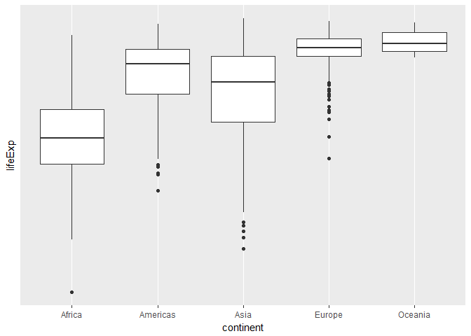

```r
boxplot
```

Now,lets look at few other plots of lifeExp such as histogram, density plot and frequency plot.

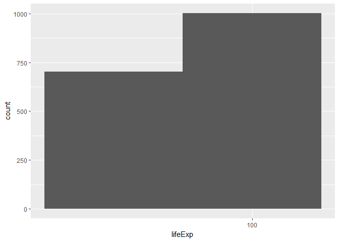

```r
hist_plot
```

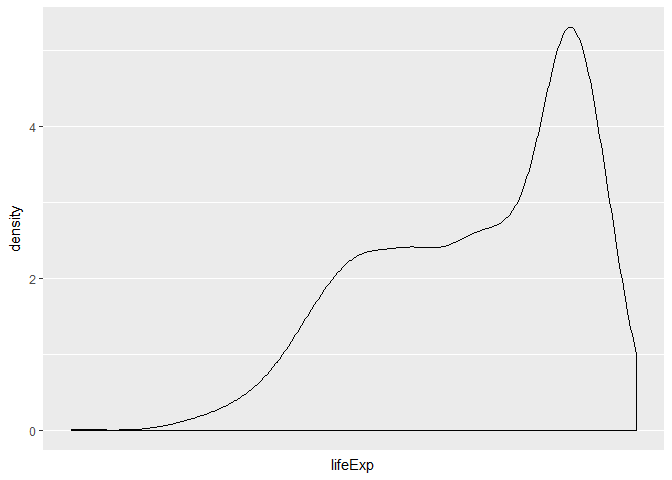

```r
density_plot
```

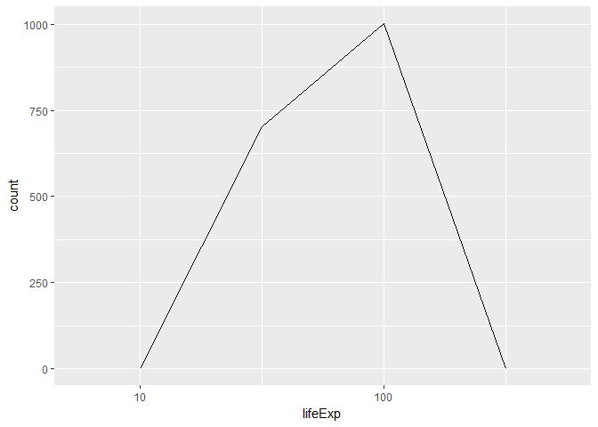

```r
freq_plot
```

Now lets take a look at the levels of continent factor variable before and after reordering.

```r
#Before
gap_clean_data$continent%>%
  levels()
```

```
## [1] "Africa"   "Americas" "Asia"     "Europe"   "Oceania"
```

```r
#After
gap_reordered$continent%>%
  levels()
```

```
## [1] "Oceania"  "Europe"   "Americas" "Asia"     "Africa"
```

Now, lets source the statistical analysis file.

```r
source('02_statistical_analysis.R')
```

Now, lets look at the fitted result table.

```r
fitted_result
```

```
## # A tibble: 140 x 7
## # Groups:   country, continent [140]
##        country continent  intercept     slope Res_Err_Std Res_Err_Variance
##         <fctr>    <fctr>      <dbl>     <dbl>       <dbl>            <dbl>
##  1 Afghanistan      Asia  -507.5343 0.2753287   1.2227880       1.49521045
##  2     Albania    Europe  -594.0725 0.3346832   1.9830615       3.93253302
##  3     Algeria    Africa -1067.8590 0.5692797   1.3230064       1.75034589
##  4      Angola    Africa  -376.5048 0.2093399   1.4070091       1.97967471
##  5   Argentina  Americas  -389.6063 0.2317084   0.2923072       0.08544349
##  6     Austria    Europe  -405.9205 0.2419923   0.4074094       0.16598240
##  7     Bahrain      Asia  -859.8258 0.4675077   1.6395865       2.68824402
##  8  Bangladesh      Asia  -936.2158 0.4981308   0.9766908       0.95392498
##  9     Belgium    Europe  -340.2412 0.2090846   0.2929025       0.08579187
## 10       Benin    Africa  -612.8340 0.3342329   1.1746910       1.37989891
## # ... with 130 more rows, and 1 more variables: R_squared <dbl>
```

Here is a look at one of the saved figures containing lifeExp vs year for each country in Oceania continent with regression line laid.

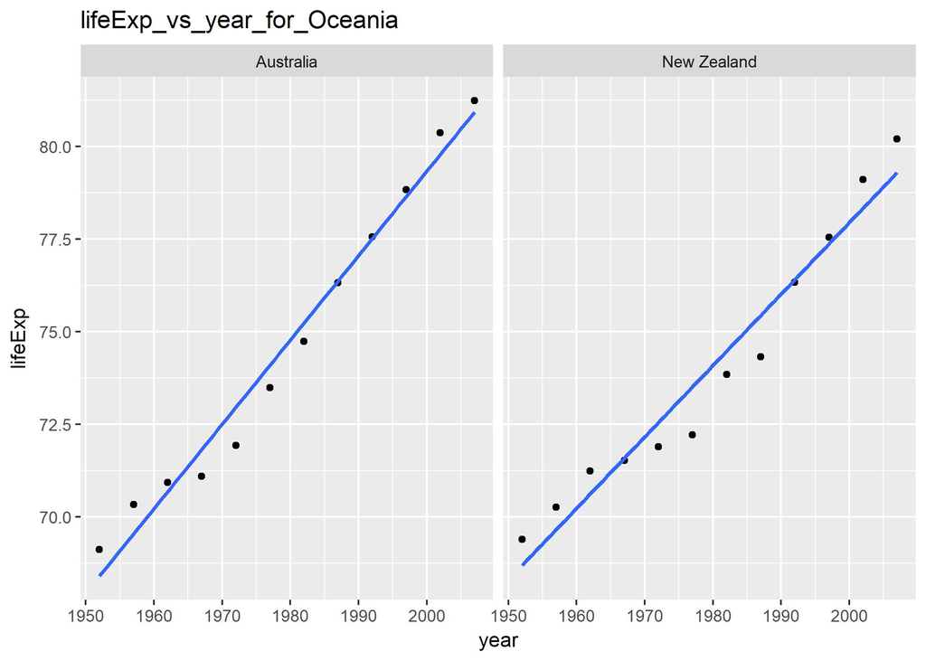

```r
best_countries%>%
  select(country,continent,intercept,slope,R2_norm,std_norm)%>%
  tableFormat(title = "Best countries in Each Continent")
```

Best countries in Each Continent

| country | continent | intercept | slope | R2_norm | std_norm |
| --- | --- | --- | --- | --- | --- |
| France | Europe | -397.7646 | 0.2385014 | 1.0000000 | 0.0799057 |
| Sweden | Europe | -252.9239 | 0.1662545 | 0.9978525 | 0.0768994 |
| Switzerland | Europe | -364.3421 | 0.2222315 | 0.9997657 | 0.0780409 |
| Argentina | Americas | -389.6063 | 0.2317084 | 0.9975158 | 0.1421767 |
| Brazil | Americas | -709.9427 | 0.3900895 | 1.0000000 | 0.1586794 |
| Canada | Americas | -358.3489 | 0.2188692 | 0.9983348 | 0.1212330 |
| Indonesia | Asia | -1201.9366 | 0.6346413 | 0.9998642 | 0.1146592 |
| Iran | Asia | -924.4620 | 0.4966399 | 0.9977595 | 0.1180490 |
| Israel | Asia | -455.0911 | 0.2671063 | 0.9975264 | 0.0649611 |
| Pakistan | Asia | -748.3836 | 0.4057923 | 1.0000000 | 0.0715672 |
| Comoros | Africa | -839.1671 | 0.4503909 | 0.9991745 | 0.0664286 |
| Equatorial Guinea | Africa | -571.0228 | 0.3101706 | 0.9991925 | 0.0456170 |
| Mali | Africa | -702.4815 | 0.3768098 | 0.9977719 | 0.0668388 |
| Mauritania | Africa | -831.3813 | 0.4464175 | 1.0000000 | 0.0565590 |

```r
worst_countries%>%
  select(country,continent,intercept,slope,R2_norm,std_norm)%>%
  tableFormat(title = "Worst countries in Each Continent")
```

Worst countries in Each Continent

| country | continent | intercept | slope | R2_norm | std_norm |
| --- | --- | --- | --- | --- | --- |
| Bulgaria | Europe | -218.64725 | 0.1456888 | 0.5478435 | 0.9111365 |
| Montenegro | Europe | -509.69710 | 0.2930014 | 0.8037745 | 1.0000000 |
| Poland | Europe | -318.23836 | 0.1962189 | 0.8416624 | 0.5887156 |
| Romania | Europe | -243.28540 | 0.1574014 | 0.8074848 | 0.5309380 |
| Jamaica | Americas | -369.50089 | 0.2213944 | 0.8072352 | 1.0000000 |
| Trinidad and Tobago | Americas | -276.93502 | 0.1736615 | 0.7995687 | 0.8035163 |
| Cambodia | Asia | -735.78684 | 0.3959028 | 0.6404537 | 1.0000000 |
| Iraq | Asia | -409.01741 | 0.2352105 | 0.5472894 | 0.7206027 |
| Korea, Dem. Rep. | Asia | -562.75907 | 0.3164266 | 0.7050021 | 0.6905999 |
| Botswana | Africa | -65.49586 | 0.0606685 | 0.0341027 | 0.8482737 |
| Rwanda | Africa | 132.20498 | -0.0458315 | 0.0171996 | 0.9101842 |
| Zambia | Africa | 165.60797 | -0.0604252 | 0.0599759 | 0.6285138 |
| Zimbabwe | Africa | 236.79819 | -0.0930210 | 0.0563630 | 1.0000000 |